# Hausuebung

Arleen Lindenmeyer

4 Juni 2019

# 1.

## Aendern des Arbeitsverzeichnisses, Einlesen der CSV-Datei “hu_pre-post_miss.csv” und Zuweisung dieser zu dem Objekt “dat.1”:

```r
setwd("C:/Users/Arleen/Desktop")
dat.1 <- read.csv2("Rdat/hu_pre-post_miss.csv")
```

# 2.

## Datenkontrolle

### Die ersten 6 Faelle des Datensatzes:

```r
head(dat.1)
```

```
##   id group wohl0 wohl1 lern0 lern1
## 1  1     0    47    44    46    45
## 2  2     0    44    NA    45    45
## 3  3     0    44    44    42    42
## 4  4     0    47    46    46    46
## 5  5     0    44    46    44    45
## 6  6     0    42    42    43    43
```

### Die letzten 6 Faelle des Datensatzes:

```r
tail(dat.1)
```

```
##      id group wohl0 wohl1 lern0 lern1
## 245 245     1    45    NA    44    43
## 246 246     1    43    42    42    42
## 247 247     1    43    42    43    43
## 248 248     1    43    43    43    44
## 249 249     1    44    43    44    44
## 250 250     1    45    47    46    46
```

# 3.

## Laden des Paketes mice, erstellen von 20 imputierten Datensaetzen vom Datensatz “hu_pre-post_miss.csv”

### Erzeugen einer leeren Imputation:

```r
library(mice)
imp1 <- mice(dat.1, maxit = 0)
```

### Imputationsmethode extrahieren:

```r
impmeth1 <- imp1$method
```

### Praedikatormatrix extrahieren:

```r
predmat1 <- imp1$predictorMatrix
```

### Praediktormatrix sinnvoll modifizieren, indem die id-Variable ausgeschlossen wird:

```r
predmat1[, "id"] <- 0
```

### Multiple Imputation mit der Funktion mice():

```r
imp1.res <- mice(dat.1, m = 20,
                method = impmeth1,
                predictorMatrix = predmat1,
                visitSequence = "monotone",
                maxit = 30,
                seed = 123)
```

### Beurteilung der Konvergenz mittels trace plots:

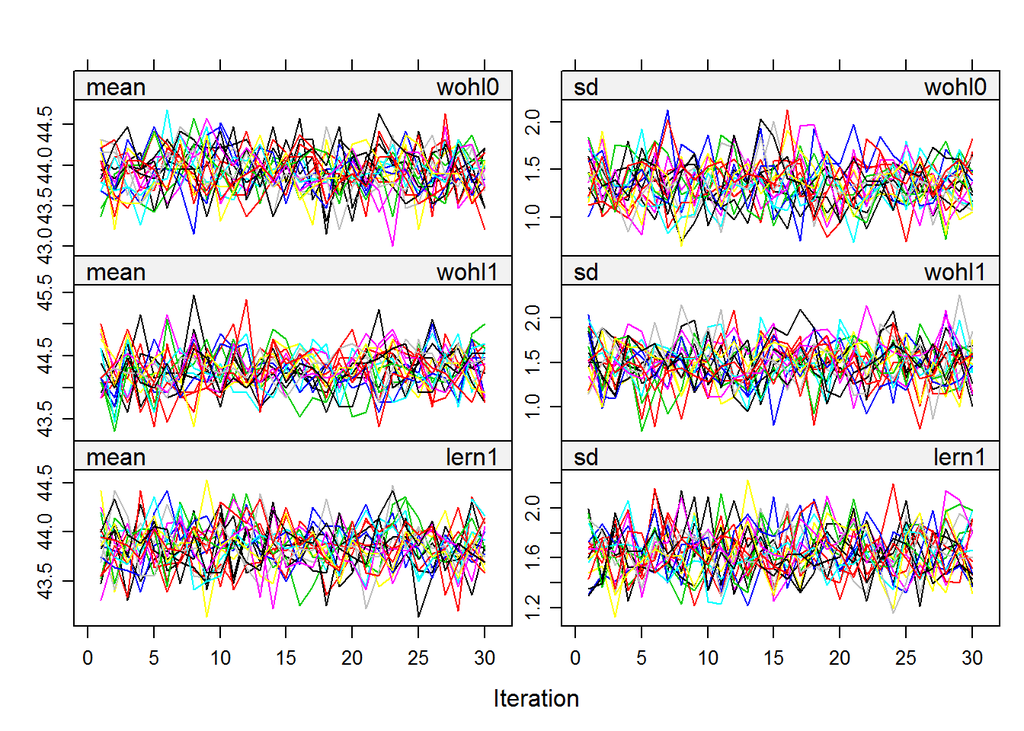

```r
plot(imp1.res)
```

### Die Ketten ueberlappen sich stark (d.h. sie pendeln sich in einen stabilen Parameter ein), deshalb ist davon auszugehen, dass keine Konvergenzprobleme vorliegen.

# 4.

## Regression von Lernmotivation im Posttest auf Interventionsgruppe, Wohlbefinden zum Pretest und Lernmotivation zum Pretest:

```r
fit1.lm <- with(imp1.res, lm(lern1 ~ group + wohl0 + lern0))
fit1.lm
```

```
## call :
## with.mids(data = imp1.res, expr = lm(lern1 ~ group + wohl0 +
##     lern0))
##
## call1 :
## mice(data = dat.1, m = 20, method = impmeth1, predictorMatrix = predmat1,
##     visitSequence = "monotone", maxit = 30, seed = 123)
##
## nmis :
##    id group wohl0 wohl1 lern0 lern1
##     0     0    19    13     0    36
##
## analyses :
## [[1]]
##
## Call:
## lm(formula = lern1 ~ group + wohl0 + lern0)
##
## Coefficients:
## (Intercept)        group        wohl0        lern0
##     16.9157       0.3126      -0.1084       0.7216
##
##
## [[2]]
##
## Call:
## lm(formula = lern1 ~ group + wohl0 + lern0)
##
## Coefficients:
## (Intercept)        group        wohl0        lern0
##     16.9711       0.4439      -0.1131       0.7241
##
##
## [[3]]
##
## Call:
## lm(formula = lern1 ~ group + wohl0 + lern0)
##
## Coefficients:
## (Intercept)        group        wohl0        lern0
```

[output cut: 156 more lines]

```
## lm(formula = lern1 ~ group + wohl0 + lern0)
##
## Coefficients:
## (Intercept)        group        wohl0        lern0
##     18.1760       0.4416      -0.1564       0.7389
##
##
## [[20]]
##
## Call:
## lm(formula = lern1 ~ group + wohl0 + lern0)
##
## Coefficients:
## (Intercept)        group        wohl0        lern0
##    16.46482      0.41631     -0.03303      0.65600
```

### Fuer jeden der imputierten Datensaetze bekommt man ein (von den anderen Ergebnissen verschiedenes) Ergebnis, also 20 verschiedene Ergebnisse insgesamt.

### Die 20 Ergebnisse der Regression k?nnen nach den Formeln von Rubin zusammengepasst werden (pooling).

## Ergebnisse nach den Formeln von Rubin poolen und Zusammenfassung ausgeben lassen:

```r
fit1.lm.pool <- pool(fit1.lm)
round(summary(fit1.lm.pool), digits = 3)
```

```
##             estimate std.error statistic      df p.value
## (Intercept)   16.625     3.057     5.439 163.066   0.000
## group          0.413     0.181     2.280 172.622   0.024
## wohl0         -0.099     0.078    -1.272 108.067   0.206
## lern0          0.718     0.070    10.224 131.963   0.000
```

### Die Auspraegung der Lernmotivation im Posttest bei Konstanthalten der Praediktoren Wohlbefinden zum Pretest und Lernmotivation zum Pretest auf 0 ist in der Kontrollgruppe 16.625 (Intercept). Bei Konstanthalten der jeweils anderen Praediktoren zeigt sich ein positiver, signifikanter Zusammenhang zwischen der Lernmotivation im Pretest und der Lernmotivation im Posttest und der Gruppenzugehoerigkeit und der Lernmotivation im Posttest (siehe Slopes und p-Werte). Aus dem Zusammenhang zwischen Gruppenzugehoerigkeit und der Lernmotivation im Posttest wuerde man schliessen, dass das neue Unterreichtskonzept im Vergleich zum regulaeren Unterricht wirksamer die Lernmotivation der Schueler steigert. Das Wohlbefinden im Pretest sagt die Lernmotivation im Posttest nicht signifikant vorher.

# 5.

## Regression mit dat.1, listenweiser Ausschluss bei fehlenden Werten:

```r
list1.lm <- with(dat.1, lm(lern1 ~ group + wohl0 + lern0))
summary(list1.lm)
```

```
##
## Call:
## lm(formula = lern1 ~ group + wohl0 + lern0)
##
## Residuals:
##     Min      1Q  Median      3Q     Max
## -3.8887 -0.8516  0.0101  0.9968  3.2919
##
## Coefficients:
##             Estimate Std. Error t value Pr(>|t|)
## (Intercept) 15.28243    3.35585   4.554 9.31e-06 ***
## group        0.36718    0.19330   1.900    0.059 .
## wohl0       -0.09835    0.07633  -1.289    0.199
## lern0        0.74729    0.07227  10.340  < 2e-16 ***
## ---
## Signif. codes:  0 '***' 0.001 '**' 0.01 '*' 0.05 '.' 0.1 ' ' 1
##
## Residual standard error: 1.348 on 193 degrees of freedom
##   (53 observations deleted due to missingness)
## Multiple R-squared:  0.4051, Adjusted R-squared:  0.3958
## F-statistic: 43.81 on 3 and 193 DF,  p-value: < 2.2e-16
```